# MA 415/615 Project 2 Part 1: Buoy 46035

Mar 19, 2018

## Introduction

In this project, we will

1. read, clean, and organize the data from the website for NOAA Weather Station buoy 46035 at 57.026 N 177.738 W in the NOAA National Data Buoy Center
2. produce a time series composed of 30 years of daily Air Temperature and Sea Temperature readings recorded at noon
3. visualize and explore the correlation between air temperature and sea temperature
4. test whether the mean temperature changed over the past 30 years

## Data Engineering

Step One: Import 30 annual datasets (1988-2017) recorded by buoy 46035 from website NOAA and combine them into one big set

1. The whole dataset of 2013 is missing, skip it
2. Before 2005 the data don't have minute(mm) column, we add them back
3. Since 2007, the data has a redundant first row about unit, we delet them
4. Put '19' in front of 2 digit years
5. Filter the data by year, month, day, hout, minute, and air & sea temperature

## Data Engineering

Step Two: Keep Cleaning the combined whole data set

1. Filter by the time at noon, 11:50 or 12:00
2. Change sea temp and air temp to numeric form
3. Convert all missing data (which is 999 or 99) into NA form
4. Combine year, month, and day to one Data column

## Build Time Series of Air Teperature

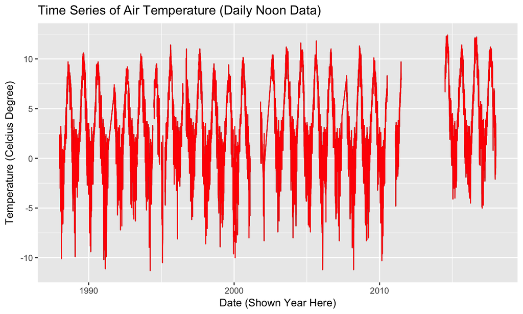

## Build Time Series of Sea Temperature

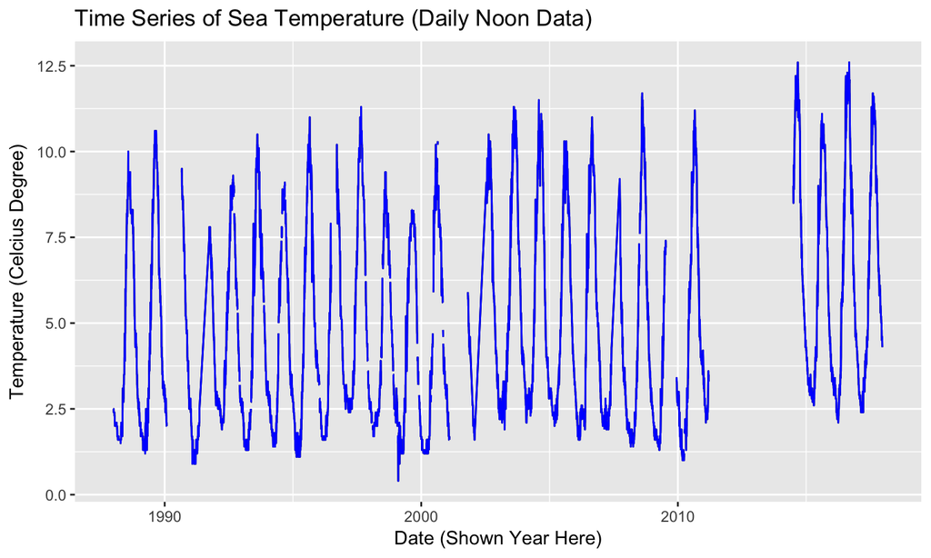

## Time Series of Air and Sea Temperature

By looking the combined time series chart, we think air temp and sea temp are correlated. We will test this later

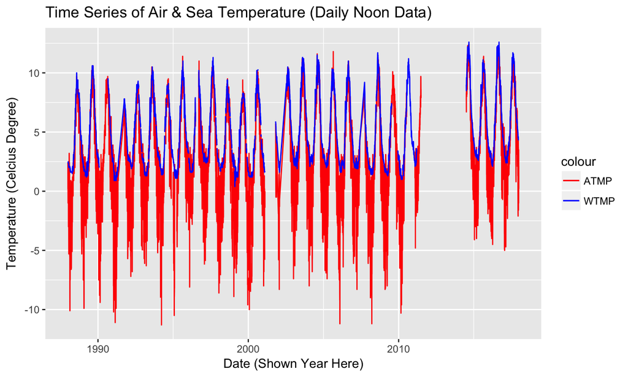

## Scatter Plot to See the Correlation between ATMP and WTMP

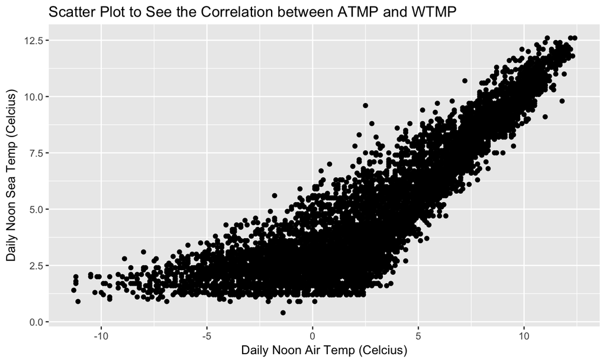

## Smooth Line to See the Correlation between ATMP and WTMP

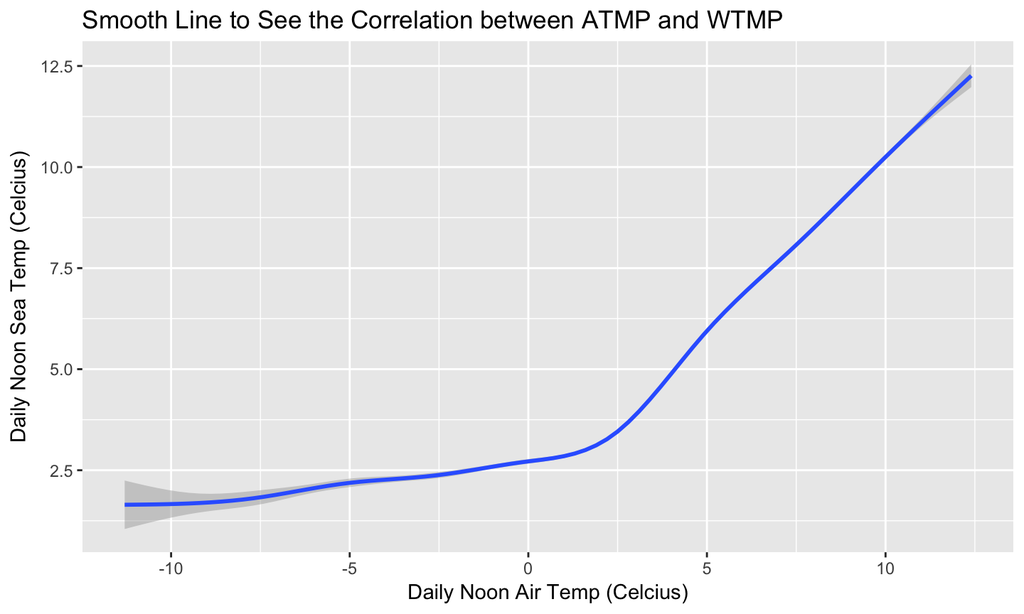

## Test the Correlation

By conducting Pearson Correlation Test, we find ATMP and WTMP have significant coefficient of correlation of 0.8774953 with p-value < 2.2e-16. Therefore, we conclude that ATMP and WTMP do have strong positive correlation.

```r
cor.test(Noon_Data$ATMP, Noon_Data$WTMP, method = "pearson")
```

```
##
##  Pearson's product-moment correlation
##
## data:  Noon_Data$ATMP and Noon_Data$WTMP
## t = 163.7, df = 8005, p-value < 2.2e-16
## alternative hypothesis: true correlation is not equal to 0
## 95 percent confidence interval:
##  0.8723586 0.8824382
## sample estimates:
##       cor
## 0.8774953
```

## Test Whether Air Temperature Changed from 1988 to 2017 (Noon_Data)

\(H_{0}:\mu _{air,noon, 1988} - \mu _{air,noon, 2017} = 0\) \(H_{a}:\mu _{air,noon, 1988} - \mu _{air,noon, 2017} \neq 0\)

## Test Whether Air Temperature Changed from 1988 to 2017 (Noon_Data)

To see whether the mean air temp changed over 30 years, we need to do t-test and create datasets which are only for 1988 and 2017

```r
Noon_1988 <- Noon_Data %>%
     separate(Date, into = c("YYYY", "MM", "DD"), sep = "-")
Noon_1988 <- filter(Noon_1988, YYYY == 1988)

Noon_2017 <- Noon_Data %>%
    separate(Date, into = c("YYYY", "MM", "DD"), sep = "-")
Noon_2017 <- filter(Noon_2017, YYYY == 2017)
```

## Test Result

Because the p-value = 5.153e-13 < 0.01, we reject the null hypothesis that the means of ATMP in 1988 and in 2017 are equal and conclude that air temp indeed changed over 30 years.

```r
t.test(Noon_1988$ATMP, Noon_2017$ATMP)
```

```
##
##  Welch Two Sample t-test
##
## data:  Noon_1988$ATMP and Noon_2017$ATMP
## t = -7.3576, df = 714.81, p-value = 5.153e-13
## alternative hypothesis: true difference in means is not equal to 0
## 95 percent confidence interval:
##  -2.932013 -1.696850
## sample estimates:
## mean of x mean of y
##  2.330748  4.645179
```

## Test Whether Sea Temperature Changed from 1988 to 2017 (Noon_Data)

\(H_{0}:\mu _{sea,noon, 1988} - \mu _{sea,noon, 2017} = 0\) \(H_{a}:\mu _{sea,noon, 1988} - \mu _{sea,noon, 2017} \neq 0\)

## Test Result

Because the p-value = 9.035e-13 < 0.01, we reject the null hypothesis that the means of WTMP in 1988 and in 2017 are equal and conclude that sea temp indeed changed over 30 years.

```r
t.test(Noon_1988$WTMP, Noon_2017$WTMP)
```

```
##
##  Welch Two Sample t-test
##
## data:  Noon_1988$WTMP and Noon_2017$WTMP
## t = -7.2784, df = 705.18, p-value = 9.035e-13
## alternative hypothesis: true difference in means is not equal to 0
## 95 percent confidence interval:
##  -1.991658 -1.145432
## sample estimates:
## mean of x mean of y
##  4.572981  6.141525
```

## We've been instructed to use only one sample per day day out of 24 daily hourly temperature readings. Has our sampling affected our evaluation of temperature change?

## Test Whether Air Temperature Changed from 1988 to 2017 (Whole Data)

\(H_{0}:\mu _{air,whole, 1988} - \mu _{air,whole, 2017} = 0\) \(H_{a}:\mu _{air,whole, 1988} - \mu _{air,whole, 2017} \neq 0\)

## Test Whether Air Temperature Changed from 1988 to 2017 (Whole Data)

Create whole year datasets for 1988 and 2017

```r
mr2017 <- mr2017[-1,]
mr1988$ATMP <- as.numeric(mr1988$ATMP)
mr2017$ATMP <- as.numeric(mr2017$ATMP)

mr1988$ATMP <- ifelse(mr1988$ATMP > 90, NA, mr1988$ATMP)
mr2017$ATMP <- ifelse(mr2017$ATMP > 90, NA, mr2017$ATMP)
```

## Test Result

Because the p-value < 2.2e-16 < 0.01, we reject the null hypothesis that the means of ATMP in 1988 and in 2017 are equal and conclude that air temp indeed changed over 30 years. So our sampling doesn't affect our evaluation of air temperature change.

```r
t.test(mr1988$ATMP, mr2017$ATMP)
```

```
##
##  Welch Two Sample t-test
##
## data:  mr1988$ATMP and mr2017$ATMP
## t = -35.166, df = 17158, p-value < 2.2e-16
## alternative hypothesis: true difference in means is not equal to 0
## 95 percent confidence interval:
##  -2.402576 -2.148886
## sample estimates:
## mean of x mean of y
##  2.438602  4.714333
```

## Test Whether Sea Temperature Changed from 1988 to 2017 (Whole Data)

\(H_{0}:\mu _{sea,whole, 1988} - \mu _{sea,whole, 2017} = 0\) \(H_{a}:\mu _{sea,whole, 1988} - \mu _{sea,whole, 2017} \neq 0\)

## Test Result

Because the p-value < 2.2e-16 < 0.01, we reject the null hypothesis that the means of WTMP in 1988 and in 2017 are equal and conclude that sea temp indeed changed over 30 years. So our sampling doesn't affect our evaluation of sea temperature change.

```r
t.test(mr1988$WTMP, mr2017$WTMP)
```

```
##
##  Welch Two Sample t-test
##
## data:  mr1988$WTMP and mr2017$WTMP
## t = -35.089, df = 16962, p-value < 2.2e-16
## alternative hypothesis: true difference in means is not equal to 0
## 95 percent confidence interval:
##  -1.634676 -1.461710
## sample estimates:
## mean of x mean of y
##  4.608660  6.156853
```

## Conclusion

1. Air Temp and Sea Temp have strong positive correlation over 30 years
2. The reason why choosing daily noon data and whole hourly data gave us the same result of "changing mean"is that getting one noon data every day has already created a big dataset for a year (365 samples > 30 samples). Therefore, the results from daily noon data shows the situation under the normal distribution, which approches to the population data (Whole Set). Plus, each temperature recorded is correlacted with the last and next temperaature recorded, and it shows the concept of time series.